# CBA of Carbon Sequestration Potential of Kelp

Author

Natalie Smith

Published

November 20, 2024

**Introduction:**

Carbon sequestration on natural and working lands (NWL) has great potential, but most carbon markets exclude NWL. In this homework you will do a cost benefit analysis of kelp farming to sequester carbon for a carbon market. Because this is a relatively new industry, you will conduct the analysis under uncertainty.

Kelp farming is common in many parts of Asia and you will analyze the costs and benefits of a kelp farm to sequester carbon for the emerging Chinese carbon market. Consider a 1 hectare kelp farm, which has the following attributes (all monetary units are dollars):

Costs:

- The setup cost of the farm is C, which has to be paid today
- The maintenance cost of the farm is D per year

Kelp Growth

- When the farm is started, the kelp biomass is 1 ton.
- Time is measured in years. At the beginning of year t + 1, the kelp biomass is:
  $$B(t+1) = B(t) + wB(t)(1-B(t)/K)$$

Where, w is a growth rate parameter and K is the carrying capacity of kelp on a 1 hectare kelp farm. B(t) is measured in tons of biomass.

Benefits:

- Kelp sequesters carbon. The higher the biomass of kelp, the more carbon it sequesters. In this location, each ton of kelp biomass sequesters s tons of carbon per year. (For example, if s = .3 and the farm has 2 tons of kelp biomass, then the farm sequesters .6 tons of carbon that year.)
- The kelp farmer can sell carbon credits for sequestered carbon at a price of p per ton.

Questions:

## 1

*Use the following parameters: C =$10,000, D =$1,000, w = .5, K = 100, s = .5, and p =$40. The discount rate is r = .05.*

### 1.1 a)

*Write a program in R that simulates the biomass of kelp over time. Make a plot of biomass over time for 20 years.*

```r
library(tidyverse)
```

```r
#parameters
c <- 10000  # setup cost
d <- 1000    # maintenance cost
w <- 0.5     # growth rate
k <- 100     # carrying capacity
s <- 0.5     # carbon sequestration rate
p <- 40      # price per ton of carbon
r <- 0.05    # discount rate
n_time <- 20 # number of years
```

```r
# B(t+1) = B(t) + wB(t)(1 - B(t)/K)
#function to simulate kelp growth
kelp_growth <- function(Bt, w, k){
  Bt1 = Bt + w*Bt*(1 - (Bt/k))
  return(Bt1)
}
```

```r
# When the farm is started, the kelp biomass (Bt) is 1 ton.
kelp_growth(1, w, k)
```

```
[1] 1.495
```

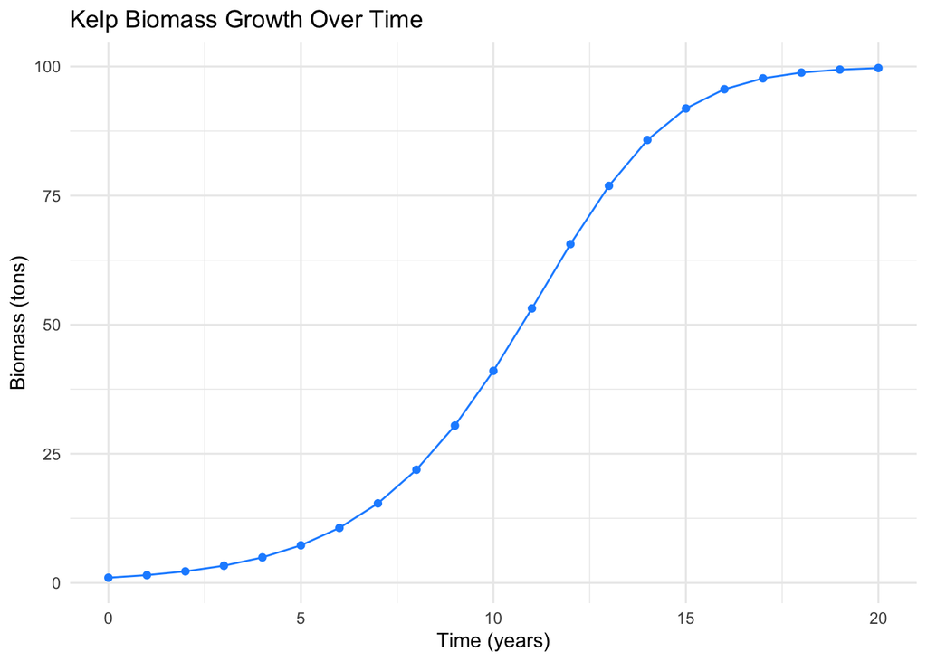

```r
# Plot biomass over 20 years

# Initialize biomass and store results
biomass <- numeric(n_time + 1)
biomass[1] <- 1 # Initial biomass of 1 ton

# Simulate biomass over 20 years
for (t in 1:n_time) {
  biomass[t + 1] <- kelp_growth(biomass[t], w, k)
}

# Create a data frame for plotting
kelp_biomass_df<- data.frame(
  year = 0:n_time,
  biomass = biomass
)

# Plot biomass over time
ggplot(kelp_biomass_df, aes(x = year, y = biomass)) +
  geom_point(color = "dodgerblue") +
  geom_line(color = "dodgerblue") +
  labs(x = "Time (years)",
       y = "Biomass (tons)",
       title = "Kelp Biomass Growth Over Time") +
  theme_minimal()
```

### 1.2 b)

*In year t = 10 what is the biomass of kelp? How much carbon is sequestered that year? What is the value of carbon credits the kelp farmer can sell that year?*

```r
#get biomass for year 10
biomass_year_10 <- kelp_biomass_df$biomass[11]
biomass_year_10
```

```
[1] 41.05482
```

```r
#carbon sequestered = biomass * carbon sequestration rate (0.5)
carbon_sequestered_year_10 <- biomass_year_10 * s
carbon_sequestered_year_10 #tons
```

```
[1] 20.52741
```

```r
#value of carbon credits farmer can sell that year
#carbon credits = carbon sequestered * price per ton of carbon
value_carbon_credit_year_10 <- carbon_sequestered_year_10 * p
value_carbon_credit_year_10
```

```
[1] 821.0963
```

The biomass in year 10 is **41.05** tons, the carbon sequestered in year 10 is **20.53** tons, and the value of carbon credits the kelp farmer can sell in year 10 is **$821.10**.

### 1.3 c)

*Plot the value of carbon credits sold against time.*

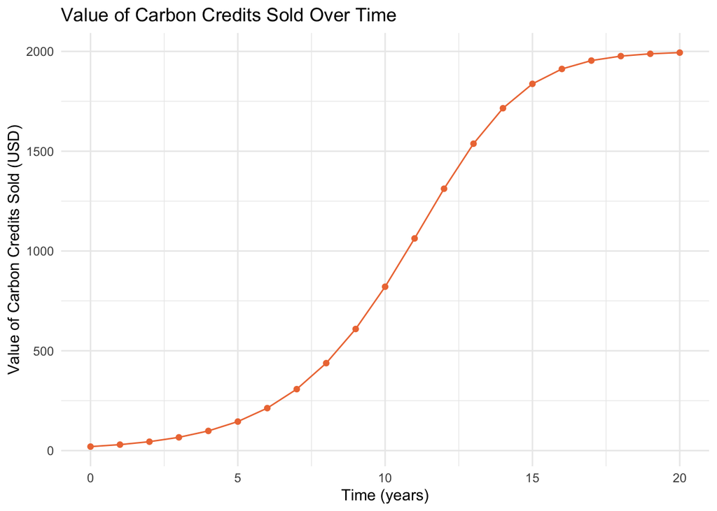

```r
#plot the value of carbon credits sold against time
carbon_credits_df <- kelp_biomass_df %>%
  mutate(tons_carbon = s * biomass,
         value_of_credit = tons_carbon *p)

# Plot value of carbon credits sold against time
ggplot(carbon_credits_df, aes(x = year, y = value_of_credit)) +
  geom_point(color = "sienna2") +
  geom_line(color = "sienna2") +
  labs(x = "Time (years)",
       y = "Value of Carbon Credits Sold (USD)",
       title = "Value of Carbon Credits Sold Over Time") +
  theme_minimal()
```

### 1.4 d)

*Plot the present value of carbon credits sold against time.*

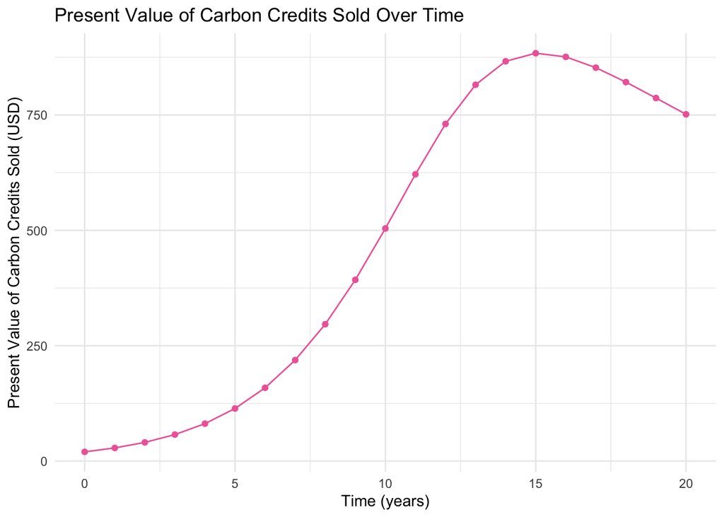

```r
# calculate value of carbon credits over time by discounting the value of carbon credits sold each year

#formula: present value = future value / (1 + r)^year

present_value_df <- carbon_credits_df %>%
  mutate(present_value_carbon_credit = value_of_credit/ (1 + r)^year)

# Plot present value of carbon credits
ggplot(present_value_df, aes(x = year, y = present_value_carbon_credit)) +
  geom_point(color = "hotpink2") +
  geom_line(color = "hotpink2") +
  labs(x = "Time (years)",
       y = "Present Value of Carbon Credits Sold (USD)",
       title = "Present Value of Carbon Credits Sold Over Time") +
  theme_minimal()
```

### 1.5 e)

*Compare the sum of present value of costs against the sum of present value of benefits over a 50 year horizon. Do the benefits of the farm outweigh the costs?*

```r
#50-year horizon

years = 50

biomass <- numeric(years + 1)
biomass[1] <- 1 #initial biomass of 1 ton


# Simulate biomass over 20 years
for (t in 1:years) {
  biomass[t + 1] <- kelp_growth(biomass[t], w, k)
}

#create df for plotting
kelp_biomass_50_df <- data.frame(
  year = 0:years,
  biomass = biomass
)

# Initialize carbon credits and store results
carbon_50_df <- kelp_biomass_50_df %>%
  mutate(tons_carbon = s * biomass,
        value_of_credit = p * tons_carbon)

# Calculate present value of carbon credits sold over time
carbon_50_df <- carbon_50_df %>%
  mutate(
      #benefits = carbon sequestered + carbon credit value
    present_value_benefits = value_of_credit / (1 + r)^(year))

# Calculate present value of costs over time
carbon_50_df <- carbon_50_df %>%
  mutate(
      #costs = maintenance cost starting from year 1 + initial setup cost at year 0
    costs = ifelse(year == 0, c, d), #C is setup, D is maintenance
         present_value_costs = costs / (1 + r)^(year)) #PV of costs


#sum present values (discounted) of costs and benefits over 50 years
total_present_value_benefits <- sum(carbon_50_df$present_value_benefits)
total_present_value__costs <- sum(carbon_50_df$present_value_costs)

#show results
total_present_value_benefits
```

```
[1] 21503.92
```

```r
total_present_value__costs
```

```
[1] 28255.93
```

### 1.6 f)

*The Chinese government is considering raising the carbon price (p). What value of p would make kelp farmers exactly break even (so present value of benefits equals present value of costs)?*

```r
#alter previous function to find where p makes kelp farmers break even

#calculate the value of p that would make kelp farmers exactly break even, where PV_benefits = PV_costs (solve for p)

npv <- function(p) {
  carbon_50_df <- kelp_biomass_50_df %>%
   mutate(tons_carbon = s * biomass,
           value_of_credit = p * tons_carbon,
           present_value_benefits = value_of_credit / (1 + r)^(year),
           costs = ifelse(year == 0, c, d), # C is setup, D is maintenance costs
           present_value_costs = costs / (1 + r)^(year)) #PV of costs

#calculate sum of PV of benefits and PV of costs
  sum_PV_benefits <- sum(carbon_50_df$present_value_benefits)
  sum_PV_costs <- sum(carbon_50_df$present_value_costs)

#return the difference (net present value) - we want it to be zero for break-even scenario
  return(sum_PV_benefits - sum_PV_costs)
}

#use a numerical solver to find the value of p that makes the CB difference equal to zero
#uniroot(f(The function for which we want to find the root), interval = c(a, b), tol = desired_tolerance, ...)

# Use uniroot to find the break-even carbon price p
break_even_price <- uniroot(npv, lower = 0, upper = 1000)$root
break_even_price
```

```
[1] 52.55957
```

The kelp farmers break even at **$52.56** per ton of carbon.

## 2

*Now supposes that you are uncertain about the parameters w (growth rate of kelp), s (carbon sequestration parameter), and p (carbon price). You believe the parameters are drawn from the following distributions:*

- *w is Normally distributed with mean .5 and standard deviation .2*
- *s is either .4, .5, or .6 (with equal probabilities)*
- *p is Normally distributed with mean 40 and standard deviation 15*

### 2.1 a)

*Write a function in R that takes any value of w, s, and p as inputs and returns the Present value of Benefits minus the present value of Costs (keeping other parameters at their values from above)*

```r
#define a function to calculate NPV given w, s, and p

calculate_npv <- function(w, s, p,
                          # define parameters that won't change
                          c = 10000,
                          d = 1000,
                          k = 100,
                          r = 0.05,
                          years = 50) {

  # Initialize biomass and store results
  biomass <- numeric(years + 1)
  biomass[1] <- 1 # Initial biomass of 1 ton

  # Simulate biomass over time using given w and K
  for (t in 1:years) {
    biomass[t + 1] <- biomass[t] + w * biomass[t] * (1 - (biomass[t] / k))
  }

  # Create df for biomass and calculate carbon credits
  new_kelp_df <- data.frame(
    Year = 0:years,
    Biomass = biomass
  ) %>%
    mutate(
      # Present value of benefits
      tons_carbon = s * Biomass,
      value = p * tons_carbon, # Value of carbon credits for each year
      present_value_benefits = value / (1 + r)^Year, # PV of benefits
      # Present value of costs
      costs = ifelse(Year == 0, c, d),
      present_value_costs = costs / (1 + r)^Year
    )

  # Sum present value of benefits and costs
  sum_PV_benefits <- sum(new_kelp_df$present_value_benefits)
  sum_PV_costs <- sum(new_kelp_df$present_value_costs)

  # Return NPV
  return(sum_PV_benefits - sum_PV_costs)
}
```

### 2.2 b)

*Call that function for the values w = .5, s = .5, and p = 40. What is the result?*

```r
#call the function with w = 0.5, s = 0.5, p = 40
calculate_npv(0.5, 0.5, 40)
```

```
[1] -6752.003
```

The net present value (benefits minus costs) for w = 0.5, s = 0.5, and p = 40 is **-$6752**.

### 2.3 c)

*Have R generate one value of w, s, and p from the distributions described above. Call your function for those values and show the result.*

```r
#set the seed for reproducibility
set.seed(123)

#generate a value for w, s, and p using the distributions described:
w <- rnorm(1, mean = 0.5, sd = 0.2)  # Normal distribution for w
s <- sample(c(0.4, 0.5, 0.6), 1)  #random choice from 0.4, 0.5, 0.6
p <- rnorm(1, mean = 40, sd = 15)  # Normal distribution for p

#call the function for those values
calculate_npv(w, s, p)
```

```
[1] 4152.521
```

With a set seed of 123, the NPV for the randomly generated values of w, s, and p is **$4152.52**.

### 2.4 d)

*Write an R program that draws 1,000 different combinations of w, s, and p from their respective distributions, and calls your function for each set of values. Plot a histogram of the final results.*

```r
#set the seed
set.seed(123)

#number of simulations
n_simulations <- 1000

#initialize a vector to store the results
results <- numeric(n_simulations)

#loop 1000 combinations of w, s, and p and store each NPV
for (i in 1:n_simulations) {
  w <- rnorm(1, mean = 0.5, sd = 0.2)
  s <- sample(c(0.4, 0.5, 0.6), 1)
  p <- rnorm(1, mean = 40, sd = 15)

#store the result of calculate_npv in the results vector
  results[i] <- calculate_npv(w, s, p)
}
```

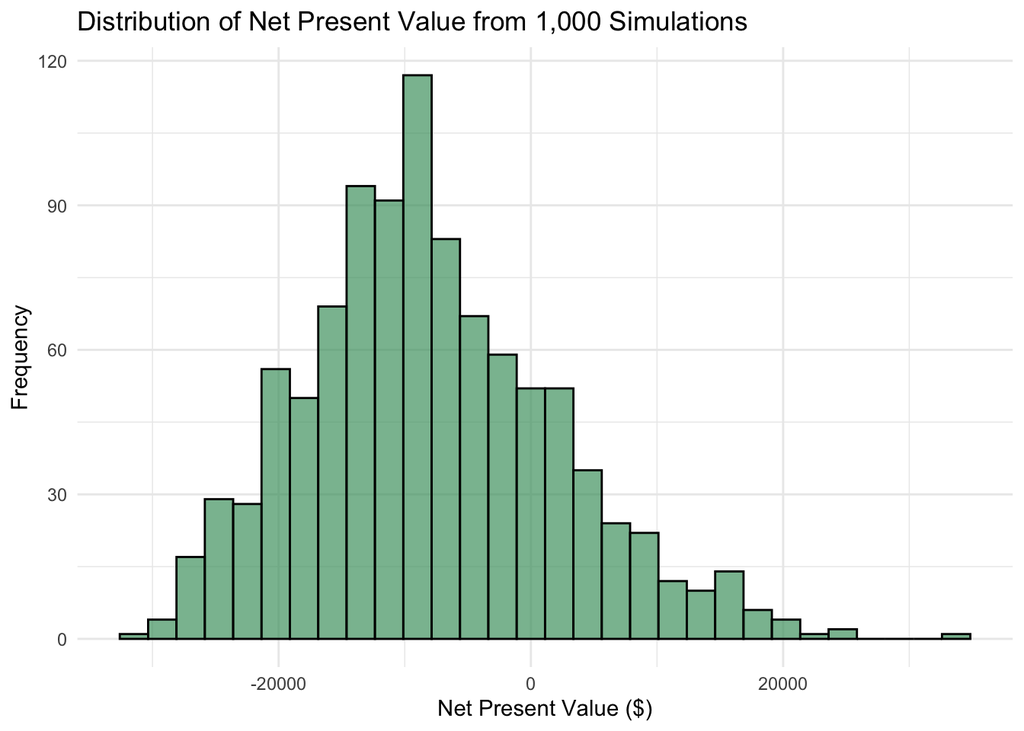

```r
#create df for ggplot
sim_results_df <- data.frame(net_present_value = results)

#histogram - make bins larger or else it looks crazy ;)
ggplot(sim_results_df, aes(x = net_present_value)) +
  geom_histogram( bins = 30,
                  fill = "#4C9F70",
                  color = "black",
                  alpha = 0.7) +
  labs(
    title = "Distribution of Net Present Value from 1,000 Simulations",
    x = "Net Present Value ($)",
    y = "Frequency") +
  theme_minimal()
```

### 2.5 e)

*Using these distributions, what is the probability that the kelp farm will have positive net present value of benefits? What is the probability that the net present value of benefits will be larger than $5,000?*

```r
#mean() function calculates the proportion of TRUE, which gives us probability

#probability of positive net present value
positive_npv <- mean(sim_results_df$net_present_value > 0)

#probability of net present value larger than $5,000
npv_above_5000 <- mean(sim_results_df$net_present_value > 5000)

#results
positive_npv
```

```
[1] 0.205
```

```r
npv_above_5000
```

```
[1] 0.108
```

The probability that the kelp farm with have a positive net present value of benefits is **0.205**. The probability that the net present value of benefits will be larger than $5,000 is **0.108**.